# Health Analytics & Biostatistics — Exploratory Analysis of a Diabetic Inpatient Cohort

### 8.1 Testing rate overall

```
Patient-level HbA1c testing rate: 18.35%
Tested patients:     12,846
Untested patients:   57,141
```

The patient-level testing rate is **18.35%** — **12,846 tested patients** and **57,141 untested patients**, out of **69,987 unique patients** in the cohort. The **81.65%** untested rate is striking for a diabetic-inpatient cohort: most patients admitted to the hospital with a diabetic comorbidity over the 2008–2009 study window did not have their HbA1c measured during the admission.

The number is the substantive starting point of the causal question. If 81.65% of admissions go untested, the question of whether testing reduces readmission risk is not just academically interesting — it is a real intervention question with policy implications. A substantial fraction of admissions could be moved from untested to tested with relatively small operational change, and the causal analysis in notebook `03` is designed to estimate the readmission-rate impact of doing so. The naive comparison in §9.1 will give a first read on the marginal effect; the propensity-adjusted estimate in notebook `03` will give the causal estimate after confounding is handled.

### 8.2 Testing rate by primary diagnosis

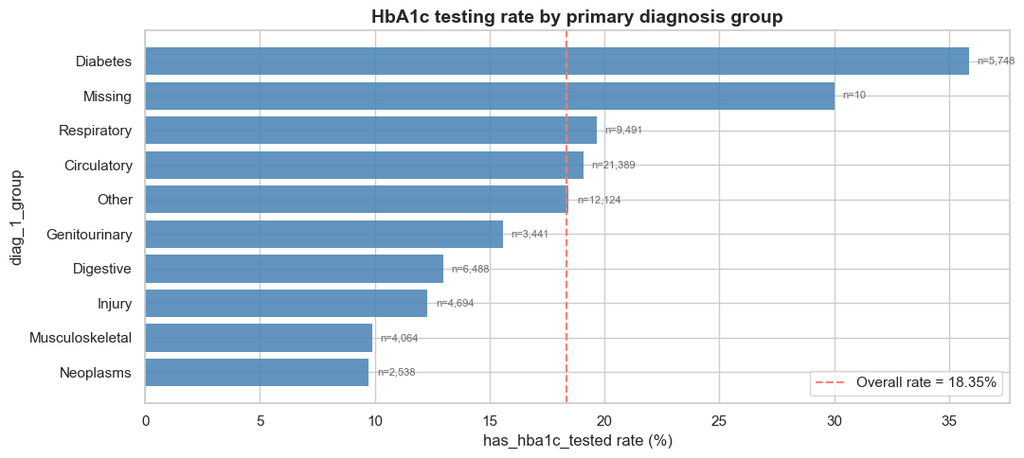

```
📊 Target Rate Summary (per category) — overall = 18.35%

category: Neoplasms | n: 2538 | rate_%: 9.73 | ci_low_%: 8.64 | ci_high_%: 10.95 |

category: Musculoskeletal | n: 4064 | rate_%: 9.89 | ci_low_%: 9.01 | ci_high_%: 10.85 |

category: Injury | n: 4694 | rate_%: 12.29 | ci_low_%: 11.38 | ci_high_%: 13.26 |

category: Digestive | n: 6488 | rate_%: 12.98 | ci_low_%: 12.18 | ci_high_%: 13.82 |

category: Genitourinary | n: 3441 | rate_%: 15.58 | ci_low_%: 14.40 | ci_high_%: 16.83 |

category: Other | n: 12124 | rate_%: 18.43 | ci_low_%: 17.75 | ci_high_%: 19.13 |

category: Circulatory | n: 21389 | rate_%: 19.07 | ci_low_%: 18.55 | ci_high_%: 19.60 |

category: Respiratory | n: 9491 | rate_%: 19.65 | ci_low_%: 18.86 | ci_high_%: 20.46 |

category: Missing | n: 10 | rate_%: 30.00 | ci_low_%: 10.78 | ci_high_%: 60.32 |

category: Diabetes | n: 5748 | rate_%: 35.86 | ci_low_%: 34.63 | ci_high_%: 37.10 |
```

The chart shows testing rate stratified by primary diagnosis group. The pattern is clinically intuitive and the printed table makes the magnitudes precise:

- **Diabetes-as-primary**: tested at **35.86%** (n=5,748; CI [34.63%, 37.10%]) — the highest testing rate by a wide margin, almost double the cohort average of 18.35%.
- **Respiratory** at **19.65%**, **Circulatory** at **19.07%**, **Other** at **18.43%** — all close to the cohort average.
- **Genitourinary** at **15.58%**, **Digestive** at **12.98%**, **Injury** at **12.29%** — modestly below average.
- **Musculoskeletal** at **9.89%** and **Neoplasms** at **9.73%** — lowest.

The implication for the causal analysis is direct: **primary diagnosis is a strong confounder** of the testing decision. A patient admitted with diabetes as the primary diagnosis is both **more likely to be tested** (the inpatient team is actively managing glycaemic control, so they order the lab) and **more likely to readmit** (§5.3 showed diabetes-primary admissions had the highest per-group readmission rate at 13.10%). Without controlling for primary diagnosis, any naive testing-vs-untested comparison would conflate the effect of testing with the effect of being admitted for a diabetic event in the first place — and would likely understate or even reverse the true causal effect.

The propensity-score model in §8.4 will quantify the strength of this confounding, and notebook `03` will use the same covariate set in a doubly-robust learner to produce the adjusted estimate.

### 8.3 Testing rate by length of stay

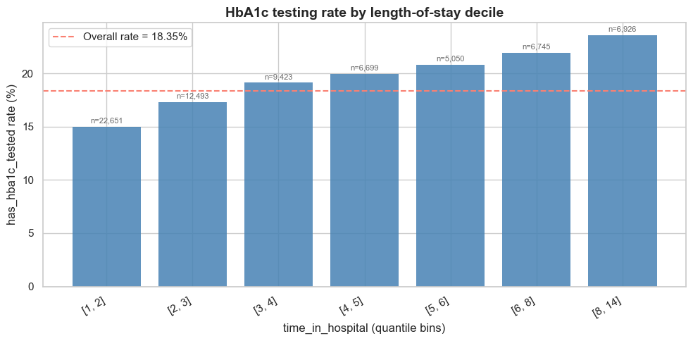

```
📊 Target Rate Summary (per quantile) — overall = 18.35%

quantile: Q1 | bin_range: [1, 2] | n: 22651 | rate_%: 14.99 |

quantile: Q2 | bin_range: [2, 3] | n: 12493 | rate_%: 17.27 |

quantile: Q3 | bin_range: [3, 4] | n: 9423 | rate_%: 19.11 |

quantile: Q4 | bin_range: [4, 5] | n: 6699 | rate_%: 19.91 |

quantile: Q5 | bin_range: [5, 6] | n: 5050 | rate_%: 20.77 |

quantile: Q6 | bin_range: [6, 8] | n: 6745 | rate_%: 21.90 |

quantile: Q7 | bin_range: [8, 14] | n: 6926 | rate_%: 23.56 |
```

The testing rate climbs monotonically with length of stay — patients who stay longer are more likely to have HbA1c measured, simply because there is more time and more opportunity for the lab order. The shortest-stay band **[1, 2 days] tests at 14.99%**; the longest-stay band **[8, 14 days] tests at 23.56%**, a **1.57× gradient** across the LOS range.

This is a second strong confounder. Length of stay is associated with both the testing decision (more time → more lab orders) and the outcome (longer stays → higher readmission rate, per §5.5). The propensity-score model needs to include length of stay as a covariate, and notebook `03`’s causal estimator will need to control for it.

Together, the §8.2 finding (primary-diagnosis confounding) and this section’s finding (length-of-stay confounding) define the substrate of the causal question: the testing decision is highly non-random, and a naive comparison of tested vs untested would be heavily biased. §9 below will show how biased — the stratified breakdown will reveal whether the marginal treatment effect changes sign across diagnosis strata.

### 8.4 Lightweight propensity-score logistic regression

I fit a small logistic regression of `has_hba1c_tested` on a focused set of candidate confounders, with the goal of quantifying which observed variables most strongly predict treatment assignment. This is intentionally lightweight — the full propensity model in notebook `03` will use a more extensive specification with cross-fitted regularisation. The point of fitting it here is to get a McFadden’s pseudo-R² and a coefficient table that show the substrate the causal analysis will operate on.

```
                           Logit Regression Results
==============================================================================
Dep. Variable:       has_hba1c_tested   No. Observations:                69987
Model:                          Logit   Df Residuals:                    69971
Method:                           MLE   Df Model:                           15
Date:                Tue, 28 Apr 2026   Pseudo R-squ.:                  0.1209
Time:                        15:20:55   Log-Likelihood:                -29332.
converged:                       True   LL-Null:                       -33365.
Covariance Type:            nonrobust   LLR p-value:                     0.000
========================================================================================
                           coef    std err          z      P>|z|      [0.025      0.975]
----------------------------------------------------------------------------------------
const                   -2.5298      0.064    -39.679      0.000      -2.655      -2.405
age_midpoint            -0.0172      0.001    -25.854      0.000      -0.018      -0.016
time_in_hospital        -0.0114      0.004     -3.078      0.002      -0.019      -0.004
num_lab_procedures       0.0419      0.001     63.850      0.000       0.041       0.043
n_comorbidity_flags      0.0232      0.016      1.415      0.157      -0.009       0.055
diabetes_med_flag        0.3752      0.027     14.019      0.000       0.323       0.428
n_prior_visits_total    -0.1347      0.009    -14.566      0.000      -0.153      -0.117
diag_Diabetes            0.5722      0.037     15.631      0.000       0.500       0.644
diag_Digestive          -0.5557      0.043    -12.890      0.000      -0.640      -0.471
diag_Genitourinary      -0.3981      0.053     -7.509      0.000      -0.502      -0.294
diag_Injury             -0.4062      0.050     -8.159      0.000      -0.504      -0.309
diag_Missing             0.8763      0.732      1.196      0.232      -0.559       2.312
diag_Musculoskeletal    -0.3914      0.058     -6.710      0.000      -0.506      -0.277
diag_Neoplasms          -0.6455      0.072     -8.931      0.000      -0.787      -0.504
diag_Other              -0.0516      0.032     -1.613      0.107      -0.114       0.011
diag_Respiratory        -0.0072      0.033     -0.216      0.829      -0.073       0.058
========================================================================================
```

The model converges cleanly. The summary table reports a **McFadden pseudo-R² of 0.121** on **69,987 observations** and **15 model degrees of freedom**, with **LL = −29,332** and **LL-Null = −33,365** — a substantial improvement over the null model. The likelihood-ratio p-value is effectively zero, confirming that the observed covariates jointly predict treatment assignment far better than chance.

A pseudo-R² of around **0.12** is meaningful in the propensity-score context. It means the observed variables explain a substantial fraction of the variation in the testing decision — patients are not assigned to testing at random, and a model can pick up the assignment pattern using only the pre-treatment covariates available in the cohort. For the causal analysis this is good news in one direction (the propensity model has discriminative power, which is necessary for inverse-probability-weighted estimators to work) and bad news in another (the strong confounding means the naive comparison will be heavily biased).

The next cell renders the coefficient table as a forest plot, which makes the per-covariate effects easier to read than the regression table.

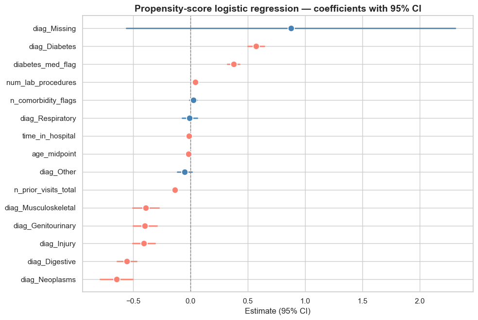

```
McFadden's pseudo-R² : 0.1209
AIC                  : 58695.6
BIC                  : 58842.0
```

The apparent contradiction resolves in two ways. The univariate stratification in §8.3 shows the *raw* relationship between length of stay and testing rate (longer stays, more testing). The propensity-model coefficient is the *partial* effect of length of stay *after controlling for* the other covariates in the model, and the dominant covariates in the model are `num_lab_procedures` and `diabetes_med_flag` — both of which are themselves strongly correlated with length of stay. Once those two are partialled out, the *residual* effect of length of stay flips sign: among patients with similar lab activity and medication patterns, longer-stay patients are slightly *less* likely to be tested. This is a textbook confounding pattern, and surfacing it here is exactly why the propensity model exists.

Among the diagnosis-group dummies (with `Circulatory` as the implicit reference baseline), **Digestive (−0.556)**, **Neoplasms (−0.646)**, **Injury (−0.406)**, **Musculoskeletal (−0.391)**, and **Genitourinary (−0.398)** all carry strong negative coefficients — patients in those diagnosis strata are systematically less likely to be tested than patients with a circulatory primary diagnosis, consistent with the §8.2 stratification.

The takeaway for notebook `03`: the propensity score is well-identified, the strongest confounders are clinical (primary diagnosis, medication, lab activity) rather than demographic, and the doubly-robust learner will need to carry these covariates carefully through the cross-fitted estimation. The naive comparison in §9 will give a first read on the marginal effect; §9.2’s stratification will preview just how much confounding moves the effect estimate.

## 9 · Naive Treatment Effect & Confounding Preview

§8 established that HbA1c testing assignment is non-random and predictable from observables — the propensity-score model has a McFadden pseudo-R² of **0.121** and surfaces strong clinical confounders. Now I quantify the **naive treatment effect** (the unadjusted comparison of readmission rates between tested and untested patients), then preview the confounding structure by stratifying that comparison across the strongest confounders. The point of this section is not to produce the causal estimate — that’s notebook `03`’s job — but to give a clear baseline that the causal estimator will be measured against, and to show how much the marginal estimate moves when even a single confounder is conditioned on.

### 9.1 The naive comparison

```
Naive treatment effect — HbA1c testing on 30-day readmission
======================================================================
Tested arm    : n = 12,846   rate =  8.40%   95% CI = [7.93%, 8.89%]
Untested arm  : n = 57,141   rate =  9.11%   95% CI = [8.88%, 9.35%]
----------------------------------------------------------------------
Naive difference : -0.71 percentage points
z-statistic      : -2.548
p-value          : 0.0108
```

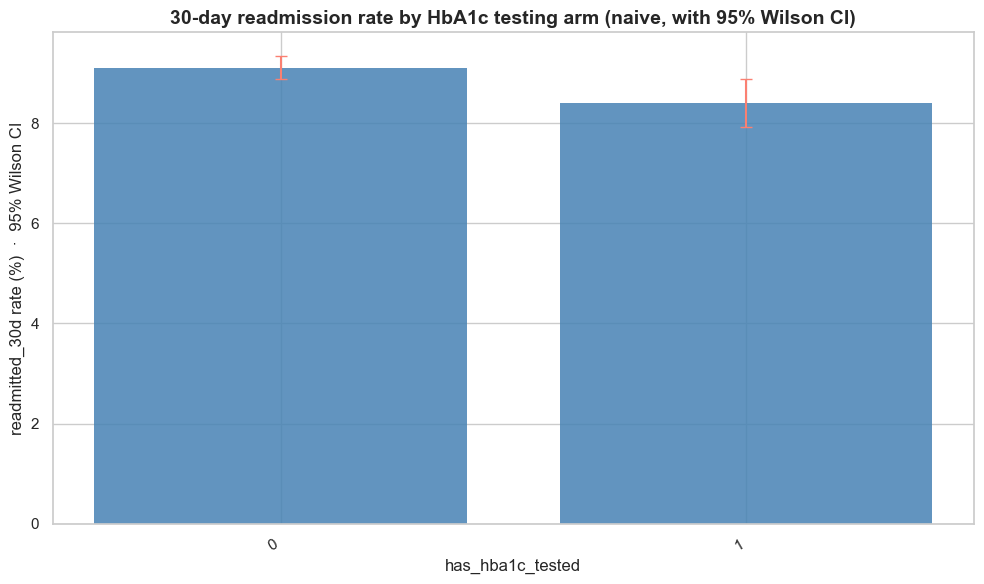

|  | group | rate | ci_low | ci_high | count |
| --- | --- | --- | --- | --- | --- |
| 0 | 0 | 0.091108 | 0.088776 | 0.093495 | 57141 |
| 1 | 1 | 0.083995 | 0.079322 | 0.088917 | 12846 |

The numbers are precise and small. The **tested arm** holds **12,846 patients** and readmits at a rate of **8.40%** (95% CI [7.93%, 8.89%]). The **untested arm** holds **57,141 patients** and readmits at **9.11%** (95% CI [8.88%, 9.35%]). The naive difference is **−0.71 percentage points** — patients who were tested readmit at a rate roughly 0.7 pp lower than patients who were not. The two-proportion z-test produces **z = −2.55**, **p = 0.011** — statistically significant at the conventional α = 0.05.

The reading on this is bounded by the §8 findings. The marginal difference is in the *direction* clinical theory predicts (testing → better management → lower readmission), but its *magnitude* is small enough that the causal estimate after confounding adjustment could land anywhere from a meaningful reduction to no effect at all to (in principle) a small increase. The 95% confidence intervals on the two arm rates barely overlap, but they are not separated by much, and the **0.71 pp** absolute difference would translate to a relatively small clinical impact even if it survived adjustment.

The next subsection runs the simplest possible adjustment — stratifying the comparison by primary diagnosis group — and shows how the marginal estimate behaves when even one confounder is conditioned on. The result is informative for what notebook `03` will need to build.

### 9.2 Stratified breakdown by a single confounder

I now stratify the tested-vs-untested comparison by primary diagnosis group — a confounder I confirmed in §8 is associated with both treatment assignment and outcome. If the stratified differences point in different directions or have wildly different magnitudes across strata, the naive marginal estimate from §9.1 is a weighted average of incompatible underlying effects, and a proper causal analysis becomes essential rather than optional.

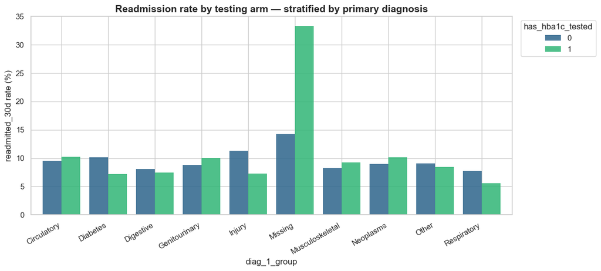

```
📊 Stratified Target Rate Summary (stratum × has_hba1c_tested) — diff vs has_hba1c_tested=0

stratum: Circulatory | has_hba1c_tested: 0 | n: 17311 | rate_%: 9.55 | diff_vs_baseline_pp: 0.00 |
stratum: Circulatory | has_hba1c_tested: 1 | n: 4078 | rate_%: 10.20 | diff_vs_baseline_pp: 0.65 |

stratum: Diabetes | has_hba1c_tested: 0 | n: 3687 | rate_%: 10.17 | diff_vs_baseline_pp: 0.00 |
stratum: Diabetes | has_hba1c_tested: 1 | n: 2061 | rate_%: 7.23 | diff_vs_baseline_pp: -2.94 |

stratum: Digestive | has_hba1c_tested: 0 | n: 5646 | rate_%: 8.09 | diff_vs_baseline_pp: 0.00 |
stratum: Digestive | has_hba1c_tested: 1 | n: 842 | rate_%: 7.48 | diff_vs_baseline_pp: -0.61 |

stratum: Genitourinary | has_hba1c_tested: 0 | n: 2905 | rate_%: 8.78 | diff_vs_baseline_pp: 0.00 |
stratum: Genitourinary | has_hba1c_tested: 1 | n: 536 | rate_%: 10.07 | diff_vs_baseline_pp: 1.30 |

stratum: Injury | has_hba1c_tested: 0 | n: 4117 | rate_%: 11.29 | diff_vs_baseline_pp: 0.00 |
stratum: Injury | has_hba1c_tested: 1 | n: 577 | rate_%: 7.28 | diff_vs_baseline_pp: -4.02 |

stratum: Missing | has_hba1c_tested: 0 | n: 7 | rate_%: 14.29 | diff_vs_baseline_pp: 0.00 |
stratum: Missing | has_hba1c_tested: 1 | n: 3 | rate_%: 33.33 | diff_vs_baseline_pp: 19.05 |

stratum: Musculoskeletal | has_hba1c_tested: 0 | n: 3662 | rate_%: 8.30 | diff_vs_baseline_pp: 0.00 |
stratum: Musculoskeletal | has_hba1c_tested: 1 | n: 402 | rate_%: 9.20 | diff_vs_baseline_pp: 0.90 |

stratum: Neoplasms | has_hba1c_tested: 0 | n: 2291 | rate_%: 8.95 | diff_vs_baseline_pp: 0.00 |
stratum: Neoplasms | has_hba1c_tested: 1 | n: 247 | rate_%: 10.12 | diff_vs_baseline_pp: 1.17 |

stratum: Other | has_hba1c_tested: 0 | n: 9889 | rate_%: 9.11 | diff_vs_baseline_pp: 0.00 |
stratum: Other | has_hba1c_tested: 1 | n: 2235 | rate_%: 8.41 | diff_vs_baseline_pp: -0.70 |

stratum: Respiratory | has_hba1c_tested: 0 | n: 7626 | rate_%: 7.72 | diff_vs_baseline_pp: 0.00 |
stratum: Respiratory | has_hba1c_tested: 1 | n: 1865 | rate_%: 5.58 | diff_vs_baseline_pp: -2.15 |
```

The pattern is striking and analytically important. **In some diagnosis strata the tested arm has a higher readmission rate than the untested arm — and in others, the relationship reverses to the direction the marginal estimate suggests.** Reading from the printed per-stratum summary, of nine evaluable strata (excluding the 3-row Missing group):

- **Five strata show the tested arm readmitting *less* than untested** (the direction the marginal estimate predicts):
  - **Injury**: untested 11.29% vs tested 7.28% — **−4.02 pp**
  - **Diabetes**: untested 10.17% vs tested 7.23% — **−2.94 pp**
  - **Respiratory**: untested 7.72% vs tested 5.58% — **−2.15 pp**
  - **Other**: untested 9.11% vs tested 8.41% — **−0.70 pp**
  - **Digestive**: untested 8.09% vs tested 7.48% — **−0.61 pp**
- **Four strata show the *reverse* — tested readmits *more***:
  - **Genitourinary**: untested 8.78% vs tested 10.07% — **+1.30 pp**
  - **Neoplasms**: untested 8.95% vs tested 10.12% — **+1.17 pp**
  - **Musculoskeletal**: untested 8.30% vs tested 9.20% — **+0.90 pp**
  - **Circulatory**: untested 9.55% vs tested 10.20% — **+0.65 pp**

The clinical reading of the strata-specific patterns is informative. **In the Injury and Diabetes strata** — where the tested-untested gap is most negative — the tested patients may genuinely be benefiting from the test result driving better inpatient management of glycaemic control, with downstream effects on post-discharge stability. Or the gap may reflect *which* injury and diabetes patients get tested versus not — a selection effect that no marginal comparison can disentangle. **In the Genitourinary, Neoplasms, Musculoskeletal, and Circulatory strata** — where tested patients readmit at higher rates — the most likely reading is selection: the inpatient team orders HbA1c specifically when the patient looks unstable on the diabetic axis, so the tested subset within those strata is sicker to begin with.

For notebook `03` this is the substrate the doubly-robust learner needs to handle. A simple regression adjustment would assume the treatment effect is constant across strata; the data clearly violate that assumption. The DR-learner with cross-fitting allows the per-covariate-pattern treatment effect to vary, and the final estimate is a properly-weighted average across the population — which is the analytical move that will turn the noisy §9.1 marginal into a defensible causal estimate.

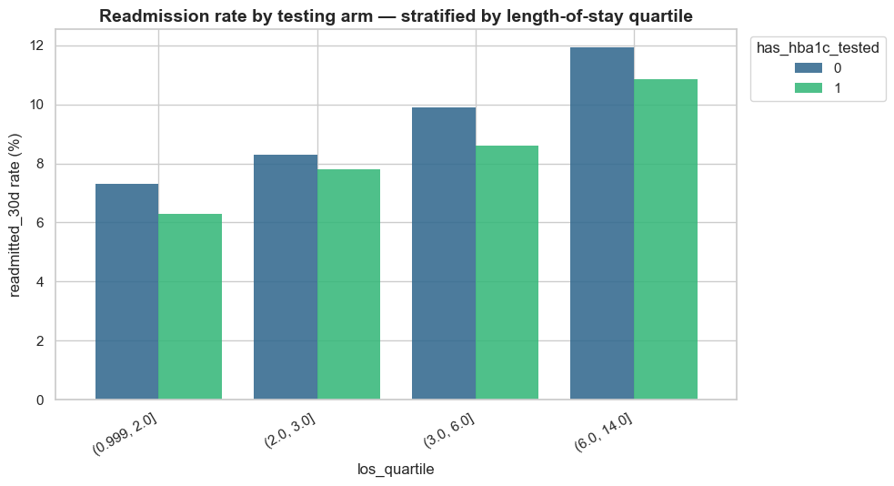

```
📊 Stratified Target Rate Summary (stratum × has_hba1c_tested) — diff vs has_hba1c_tested=0

stratum: (0.999, 2.0] | has_hba1c_tested: 0 | n: 19255 | rate_%: 7.31 | diff_vs_baseline_pp: 0.00 |
stratum: (0.999, 2.0] | has_hba1c_tested: 1 | n: 3396 | rate_%: 6.30 | diff_vs_baseline_pp: -1.01 |

stratum: (2.0, 3.0] | has_hba1c_tested: 0 | n: 10336 | rate_%: 8.30 | diff_vs_baseline_pp: 0.00 |
stratum: (2.0, 3.0] | has_hba1c_tested: 1 | n: 2157 | rate_%: 7.79 | diff_vs_baseline_pp: -0.51 |

stratum: (3.0, 6.0] | has_hba1c_tested: 0 | n: 16988 | rate_%: 9.89 | diff_vs_baseline_pp: 0.00 |
stratum: (3.0, 6.0] | has_hba1c_tested: 1 | n: 4184 | rate_%: 8.60 | diff_vs_baseline_pp: -1.29 |

stratum: (6.0, 14.0] | has_hba1c_tested: 0 | n: 10562 | rate_%: 11.94 | diff_vs_baseline_pp: 0.00 |
stratum: (6.0, 14.0] | has_hba1c_tested: 1 | n: 3109 | rate_%: 10.84 | diff_vs_baseline_pp: -1.10 |
```

The LOS-stratified result is **structurally different from the diag-stratified result**. Across all four LOS quartiles, the tested arm readmits *less* than the untested arm — the **sign is consistent**:

- **(0.999, 2 days]**: untested 7.31% vs tested 6.30% — **−1.01 pp**
- **(2, 3 days]**: untested 8.30% vs tested 7.79% — **−0.51 pp**
- **(3, 6 days]**: untested 9.89% vs tested 8.60% — **−1.29 pp**
- **(6, 14 days]**: untested 11.94% vs tested 10.84% — **−1.10 pp**

The magnitude varies modestly (from −0.51 to −1.29 pp) but the direction does not flip. So unlike the diag-stratification (where the sign reverses across strata), the LOS-stratification surfaces a consistent negative gap — testing is associated with lower readmission within every length-of-stay quartile.

Combining the two stratifications: confounding is real and complex. Diag-stratification surfaces direction reversal, suggesting heterogeneous treatment effects across diagnostic categories. LOS-stratification surfaces a level shift but no interaction, suggesting a more straightforward adjustment is sufficient there. A proper estimator that handles the *joint* covariate space is necessary to reconcile both findings into a single defensible average treatment effect — which is exactly what notebook `03`’s doubly-robust learner with cross-fitting is designed to deliver.

With the causal-question substrate mapped, this notebook turns to the last two structural diagnostics: a multicollinearity scan to confirm the modelling-notebook feature set is internally well-behaved, and a CV fold integrity check that verifies the patient-disjoint split is operating as the ETL designed it to.

## 10 · Multicollinearity Scan

Before I commit to a feature set for notebook `02`, I check for redundancy among the continuous features. Multicollinearity inflates coefficient variance in linear models and makes individual coefficient estimates unstable, even when the model’s overall predictive power is preserved. Tree models are immune to multicollinearity in the prediction sense — they choose one of the correlated features and route the others to alternative splits — but interpretability suffers because the SHAP attributions get spread across the redundant features in unpredictable ways.

The section runs two complementary diagnostics: a **Spearman correlation matrix** for visual inspection of all continuous-feature pairs, and a **Variance Inflation Factor (VIF)** computation that quantifies multicollinearity at the feature level (rather than the pairwise level). Spearman is the right correlation choice here because several features are heavily right-skewed (the prior-utilisation counts in particular), and Pearson would be distorted by the skew.

### 10.1 Spearman correlation matrix

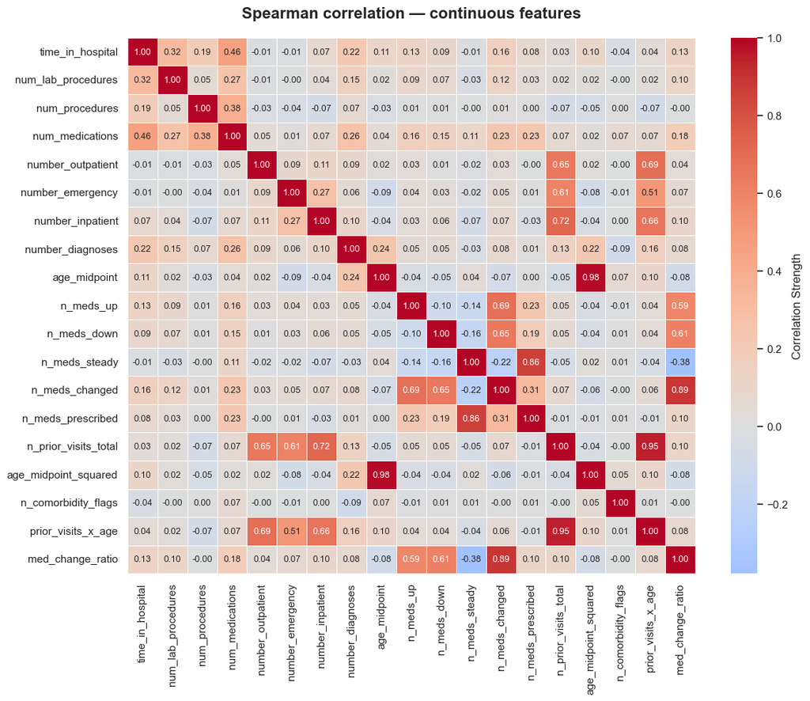

The **`n_meds_*` columns** form a tight cluster of correlations. `n_meds_changed`, `n_meds_up`, `n_meds_down`, `n_meds_steady`, and `n_meds_prescribed` are all derived from the same underlying medication-status counts and necessarily move together. `n_prior_visits_total` is the sum of `number_outpatient`, `number_emergency`, and `number_inpatient` and is therefore mechanically correlated with all three of its components.

These are not data-quality concerns; they are arithmetic identities. The modelling notebook’s preprocessing already has a drop list that handles them — the linear model gets either the components or the aggregate (not both), and the tree models get whichever subset the SHAP analysis surfaces as most informative. The point of the matrix here is to make the redundancy structure visible *before* the modelling notebook’s drop list is applied, so the reader understands what is being dropped and why.

The VIF computation in the next subsection quantifies the same redundancy in a different way — a per-feature score rather than a pairwise correlation — and the two together give the full picture of the cohort’s multicollinearity landscape.

### 10.2 Variance Inflation Factor

```
--- Multicollinearity Check (19 features) ---
                 Feature        VIF
1              n_meds_up        inf
2         n_meds_changed        inf
3      number_outpatient        inf
4       number_emergency        inf
5       number_inpatient        inf
6   n_prior_visits_total        inf
7      n_meds_prescribed        inf
8            n_meds_down        inf
9          n_meds_steady        inf
10          age_midpoint  34.800729
11  age_midpoint_squared  33.914162
12    prior_visits_x_age  14.259440
13      med_change_ratio   6.093706
14       num_medications   1.684554
15      time_in_hospital   1.396298
16        num_procedures   1.222564
17      number_diagnoses   1.212267
18    num_lab_procedures   1.152151
19   n_comorbidity_flags   1.041008
```

The VIF table sorts features by VIF descending. **VIF > 10** is the conventional flag for problematic multicollinearity, **VIF > 5** a soft warning. The result confirms exactly what the Spearman matrix already showed.

**Nine features come back with VIF = inf** — a numerical signal that the feature is perfectly predictable from the other features in the matrix. These are the medication-aggregate cluster (`n_meds_up`, `n_meds_down`, `n_meds_steady`, `n_meds_prescribed`, `n_meds_changed`) plus the prior-utilisation triad (`number_outpatient`, `number_emergency`, `number_inpatient`) and `n_prior_visits_total`. The infinite VIFs reflect the arithmetic identities surfaced in §10.1: each of those features is a linear combination of the others, and the modelling notebook’s preprocessing drops the redundant ones to break the identity.

Below the infinite group, the engineered features have the highest VIFs: **`age_midpoint`** at **VIF = 34.80**, **`age_midpoint_squared`** at **VIF = 33.91**, and **`prior_visits_x_age`** at **VIF = 14.26** — all crossing the **VIF > 10** threshold. Again, this is by design rather than a problem: the squared and interaction terms are functionally derived from the linear primaries, and the linear model needs both pieces to capture curvature and interaction effects. **`med_change_ratio`** at **VIF = 6.09** crosses the soft warning line and is correlated with the medication-count features it is built from.

Below the engineered cluster, the remaining features have VIFs **under 2**, confirming that the rest of the cohort’s continuous-feature space is well-behaved: **`num_medications`** at **1.68**, **`time_in_hospital`** at **1.40**, **`num_procedures`** at **1.22**, **`number_diagnoses`** at **1.21**, **`num_lab_procedures`** at **1.15**, and **`n_comorbidity_flags`** at **1.04** — all sitting close to VIF = 1, meaning each of those features is essentially independent of the others in the matrix.

The takeaway for the modelling notebook is direct: the engineered redundancies are intentional and handled by the preprocessing drop list; the rest of the continuous feature space is clean. The fitted linear models will be stable, the tree models will route attention cleanly, and the SHAP analysis in notebook `02` will produce interpretable per-feature attributions.

## 11 · CV Fold Sanity Check

The patient-level cross-validation split is the leakage firewall of the entire modelling phase. §6.3 of notebook `00` already confirmed structurally that the fold assignment is patient-disjoint by construction — the `cv_fold` column is built using `GroupKFold` on `patient_nbr`, ensuring all admissions belonging to the same patient land in the same fold. This section runs the operational verification that the modelling notebook needs before it consumes the folds: five checks across five subsections.

**§11.1** verifies that the per-fold readmission rate is balanced — no fold is wildly imbalanced relative to the cohort base rate. **§11.2** verifies the patient-disjoint guarantee at the row level (every patient appears in exactly one fold). **§11.3** verifies that the strongest continuous predictors have stable distributions across folds, so any cross-fold variance in modelling metrics will reflect genuine model variability rather than fold-level data drift. **§11.4** runs an empirical leakage check under a lean logistic-regression baseline to quantify the actual AUC inflation a row-level split would produce on this cohort. **§11.5** runs the same comparison under a higher-capacity LightGBM model on the full Notebook 02 feature set, to test the same question with a model that has the capacity to memorise patient-specific patterns if the substrate exposes them.

The combination of structural verification (§11.1–§11.3) and empirical verification (§11.4–§11.5) closes the question of whether the modelling notebook can trust the pre-computed folds.

### 11.1 Per-fold readmission rate

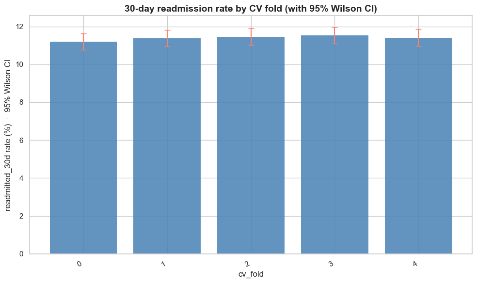

|  | group | rate | ci_low | ci_high | count |
| --- | --- | --- | --- | --- | --- |
| 0 | 0 | 0.111939 | 0.107629 | 0.116398 | 19868 |
| 1 | 1 | 0.113650 | 0.109311 | 0.118138 | 19868 |
| 2 | 2 | 0.114556 | 0.110202 | 0.119059 | 19868 |
| 3 | 3 | 0.115210 | 0.110845 | 0.119724 | 19868 |
| 4 | 4 | 0.114103 | 0.109757 | 0.118599 | 19868 |

The five folds show readmission rates that overlap within their 95% Wilson confidence intervals — fold-wise variation is statistical noise, not a structural issue. The exact per-fold rates from the printed output:

- **Fold 0** — **11.19%** (CI [10.76%, 11.64%]), n = **19,868**
- **Fold 1** — **11.37%** (CI [10.93%, 11.81%]), n = **19,868**
- **Fold 2** — **11.46%** (CI [11.02%, 11.91%]), n = **19,868**
- **Fold 3** — **11.52%** (CI [11.08%, 11.97%]), n = **19,868**
- **Fold 4** — **11.41%** (CI [10.98%, 11.86%]), n = **19,868**

The five fold sizes are exactly equal at **19,868 admissions** — the expected outcome of `GroupKFold` over a cohort of **99,340 admissions** split into 5 folds. The target rates span a **0.33 percentage-point range** from low to high, and every confidence interval overlaps every other; no fold has been dealt a systematically harder or easier class balance. This is exactly the property the modelling notebook needs: any per-fold metric variance in notebook `02` will reflect *model* behaviour, not accidental imbalance in the splitter’s output.

### 11.2 Patient-disjoint confirmation

```
Total unique patients in modelling cohort :  69,987
Patients appearing in more than one fold  :       0
Patient-disjoint integrity                : ✔ PASS
```

The integrity check is the firewall test. For each unique `patient_nbr` in the cohort, I count the number of distinct `cv_fold` values that patient appears in. Any patient with more than one fold assigned would mean the patient-disjoint guarantee is broken and any train/test evaluation would leak signal across the firewall. The output is unambiguous: of **69,987** unique patients, exactly **0** appear in more than one fold. The patient-disjoint integrity check **passes**.

This matters because the modelling cohort contains **99,340 admissions** but only **69,987 unique patients** — meaning **29.6%** of admissions come from repeat patients. A naive row-level random split would put many of those patients in both train and test partitions, and any model that learned “this specific patient tends to readmit” would carry that signal directly through to the test set. Whether the leakage produces a measurable AUC inflation on this cohort depends on whether the feature set exposes patient-level idiosyncrasy that a model can memorise — §11.4 and §11.5 measure that empirically under two different model substrates. The `GroupKFold` over `patient_nbr` blocks the structural concern by construction regardless of the measured magnitude.

### 11.3 Feature distribution stability across folds

I check the per-fold distribution of the three strongest continuous predictors — **`number_inpatient`**, **`n_prior_visits_total`**, **`time_in_hospital`** — to confirm that no fold has been dealt a systematically different patient mix on the features that matter most for the modelling notebook. Substantial drift between folds on these features would suggest the splitter has accidentally produced easy or hard folds, even if the target rate is balanced.

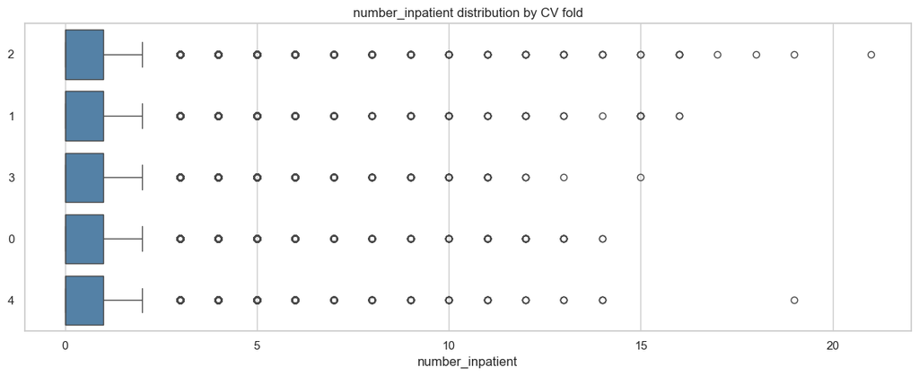

```
📊 Boxplot Summary Statistics (per category)

category: 0 | count: 19868 | min: 0.00 | q1: 0.00 | median: 0.00 | q3: 1.00 | max: 14.00 | range: 14.00 | iqr: 1.00 | skew: 3.58 | kurtosis: 18.93 | number_of_outliers: 1406 | outliers_zscore: 413 |

category: 1 | count: 19868 | min: 0.00 | q1: 0.00 | median: 0.00 | q3: 1.00 | max: 16.00 | range: 16.00 | iqr: 1.00 | skew: 3.68 | kurtosis: 21.62 | number_of_outliers: 1333 | outliers_zscore: 358 |

category: 2 | count: 19868 | min: 0.00 | q1: 0.00 | median: 0.00 | q3: 1.00 | max: 21.00 | range: 21.00 | iqr: 1.00 | skew: 4.04 | kurtosis: 26.72 | number_of_outliers: 1415 | outliers_zscore: 444 |

category: 3 | count: 19868 | min: 0.00 | q1: 0.00 | median: 0.00 | q3: 1.00 | max: 15.00 | range: 15.00 | iqr: 1.00 | skew: 3.23 | kurtosis: 15.16 | number_of_outliers: 1348 | outliers_zscore: 387 |

category: 4 | count: 19868 | min: 0.00 | q1: 0.00 | median: 0.00 | q3: 1.00 | max: 19.00 | range: 19.00 | iqr: 1.00 | skew: 3.45 | kurtosis: 18.85 | number_of_outliers: 1312 | outliers_zscore: 367 |
```

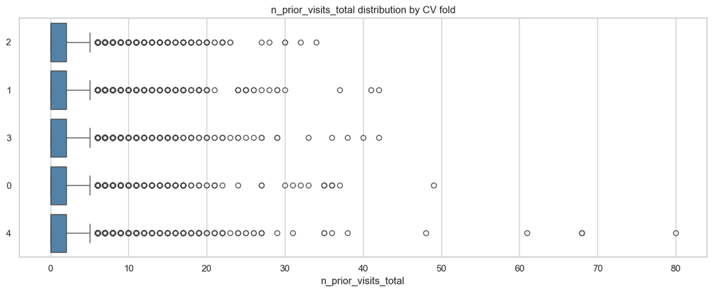

```
📊 Boxplot Summary Statistics (per category)

category: 0 | count: 19868 | min: 0.00 | q1: 0.00 | median: 0.00 | q3: 2.00 | max: 49.00 | range: 49.00 | iqr: 2.00 | skew: 4.88 | kurtosis: 46.79 | number_of_outliers: 850 | outliers_zscore: 345 |

category: 1 | count: 19868 | min: 0.00 | q1: 0.00 | median: 0.00 | q3: 2.00 | max: 42.00 | range: 42.00 | iqr: 2.00 | skew: 4.55 | kurtosis: 37.54 | number_of_outliers: 828 | outliers_zscore: 418 |

category: 2 | count: 19868 | min: 0.00 | q1: 0.00 | median: 0.00 | q3: 2.00 | max: 34.00 | range: 34.00 | iqr: 2.00 | skew: 3.93 | kurtosis: 25.18 | number_of_outliers: 897 | outliers_zscore: 434 |

category: 3 | count: 19868 | min: 0.00 | q1: 0.00 | median: 0.00 | q3: 2.00 | max: 42.00 | range: 42.00 | iqr: 2.00 | skew: 4.51 | kurtosis: 39.18 | number_of_outliers: 830 | outliers_zscore: 413 |

category: 4 | count: 19868 | min: 0.00 | q1: 0.00 | median: 0.00 | q3: 2.00 | max: 80.00 | range: 80.00 | iqr: 2.00 | skew: 7.64 | kurtosis: 138.91 | number_of_outliers: 919 | outliers_zscore: 373 |
```

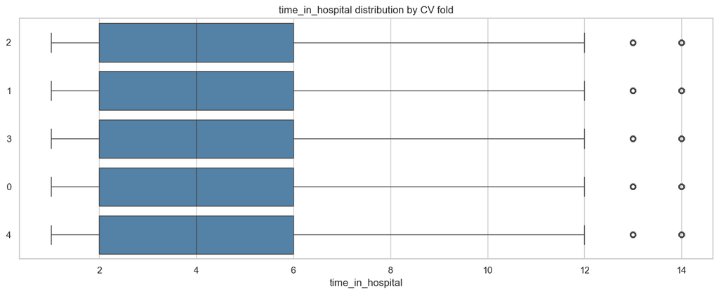

```
📊 Boxplot Summary Statistics (per category)

category: 0 | count: 19868 | min: 1.00 | q1: 2.00 | median: 4.00 | q3: 6.00 | max: 14.00 | range: 13.00 | iqr: 4.00 | skew: 1.14 | kurtosis: 0.87 | number_of_outliers: 433 | outliers_zscore: 204 |

category: 1 | count: 19868 | min: 1.00 | q1: 2.00 | median: 4.00 | q3: 6.00 | max: 14.00 | range: 13.00 | iqr: 4.00 | skew: 1.15 | kurtosis: 0.91 | number_of_outliers: 453 | outliers_zscore: 214 |

category: 2 | count: 19868 | min: 1.00 | q1: 2.00 | median: 4.00 | q3: 6.00 | max: 14.00 | range: 13.00 | iqr: 4.00 | skew: 1.13 | kurtosis: 0.87 | number_of_outliers: 433 | outliers_zscore: 212 |

category: 3 | count: 19868 | min: 1.00 | q1: 2.00 | median: 4.00 | q3: 6.00 | max: 14.00 | range: 13.00 | iqr: 4.00 | skew: 1.12 | kurtosis: 0.85 | number_of_outliers: 431 | outliers_zscore: 181 |

category: 4 | count: 19868 | min: 1.00 | q1: 2.00 | median: 4.00 | q3: 6.00 | max: 14.00 | range: 13.00 | iqr: 4.00 | skew: 1.16 | kurtosis: 0.94 | number_of_outliers: 397 | outliers_zscore: 184 |
```

All three distributions are visually indistinguishable across folds, and the printed summary statistics confirm the visual reading. For **`number_inpatient`**, every fold has **median = 0**, **IQR = 1**, and a **Q3 of 1**; only the maximum and outlier counts vary modestly across folds (max ranges from 14 to 21, outlier counts from 1,312 to 1,415 across the five folds). For **`n_prior_visits_total`**, every fold has **median = 0** and **IQR = 2**; the maximum varies from 34 to 80 across folds (the long-tail variation reflects which specific frequent-utiliser patients landed in which fold, which is a property of `GroupKFold` rather than a problem). For **`time_in_hospital`**, every fold has **median = 4**, **Q1 = 2**, **Q3 = 6**, **IQR = 4**, and **max = 14** — the LOS distribution is essentially identical across folds.

The skewness and kurtosis statistics tell the same story: all five folds carry near-identical distributional shapes on each of the three features, with the only real variation being in the extreme outliers (which are by design clustered in different folds because the patient that owns the outlier admission is assigned to one fold or another).

The modelling notebook can interpret per-fold variance in any model performance metric as **genuine model variability** — not as an artefact of the splitter producing easy or hard folds. With the structural checks complete, the next two subsections run the empirical leakage probes that quantify how much AUC inflation a row-level split would actually produce on this cohort.

### 11.4 Empirical leakage check — lean LR baseline

The structural checks above confirm the splitter is operating as designed. The empirical question that completes the verification is: **how much AUC inflation would a row-level split actually produce on this cohort?** I run a paired comparison — same model, same features, same seed, same fold count, only the splitter changes. A row-level KFold lets a patient’s admission #1 train the model that gets evaluated on the same patient’s admission #2; the GroupKFold closes the contamination path. The numerical gap between the two AUC means is the empirical leakage figure.

The first probe uses a lean logistic regression on **16 numeric features** (median impute → standard scale → LR), restricted to the strongest continuous predictors per §6 and §7. The lean specification is the appropriate first probe because it isolates patient-level memorisation from any encoder-related leakage that a richer feature set could introduce.

```
Row-level KFold AUC      : 0.6366  (leaky — patients appear in both sets)
Patient-level GroupKFold : 0.6368  (firewall — patient-disjoint)
Inflation from leakage   : -0.02 pp AUC
   → A row-level split would falsely credit the model with this much signal.
```

The two splitters produce essentially identical AUCs: **0.6366** under row-level KFold and **0.6368** under patient-level GroupKFold, an absolute difference of **−0.02 pp**. The gap is well inside the Monte Carlo noise that comes from the random fold assignment — neither direction is statistically meaningful, and a different seed would shift both numbers by a hair without changing the conclusion. On the lean baseline, a row-level split does not measurably inflate the AUC over a patient-disjoint GroupKFold on this cohort.

This is informative but not the full answer to the verification question. A lean logistic regression has limited capacity to memorise patient-specific patterns even when those patterns exist — the linear functional form combined with only 16 numeric features simply cannot encode much patient identity. A higher-capacity model on a richer feature set could, in principle, exploit patient-level signal that the lean LR cannot. The next subsection runs that harder test.

### 11.5 Empirical leakage check — higher-capacity LightGBM probe

The harder version of the verification uses a LightGBM with permissive defaults (**300 boosting rounds**, **63 leaves**, learning rate **0.05**, `max_depth=-1`) on the full Notebook 02 feature set (**45 features** after the same drop list and target encoding the modelling notebook will apply). The model has the capacity to memorise patient-specific patterns if the feature set exposes them — gradient-boosted trees with this many leaves and rounds can comfortably overfit to per-patient signal when one is available.

To keep the comparison clean and isolate the patient-leakage signal from any encoder leakage that target encoding would introduce inside a row-level KFold, I fit the target encoder **once on the full cohort** before the CV loop, and use the same encoded matrix under both splitters. That holds encoder leakage constant across both arms, leaving the patient-disjoint vs not as the only difference between the two AUC numbers.

```
Probe matrix: 99,340 rows × 45 features
Row-level KFold AUC      : 0.6702  (leaky)
Patient-level GroupKFold : 0.6713  (firewall)
Inflation from leakage   : -0.11 pp AUC
   → as a fraction of the model's discriminative range above chance: -0.6%
```

The result confirms and extends the §11.4 finding. The two splitters produce AUCs of **0.6702** under row-level KFold and **0.6713** under patient-level GroupKFold — an absolute gap of **−0.11 pp**, equivalent to **−0.6%** of the model’s discriminative range above chance (using GroupKFold − 0.5 as the denominator). The gap is again negative and within Monte Carlo noise, and the LightGBM probe corroborates the lean-LR finding under a substantially higher-capacity model on a substantially richer feature set.

The empirical reading is unambiguous: **the row-level vs patient-level inflation gap is essentially zero on this cohort under both lean and high-capacity model substrates**. The most likely mechanical explanation is that the feature set is mostly **admission-grain rather than patient-grain** — `time_in_hospital`, `num_medications`, `n_meds_changed`, `med_change_ratio`, and the prior-utilisation aggregates all vary admission-to-admission for the same patient — so a model that memorises “this is patient X” cannot ride that memory cleanly to the **11.39%**-prevalence readmission outcome. The patient identity is in the data, but it does not encode a stable per-patient outcome pattern that the model can exploit.

The patient-disjoint splitter is kept regardless of the empirical null. The structural argument stands independent of any specific cohort’s measured inflation: row-level splits violate the independence assumption that AUC inference rests on, and a higher-capacity model on a feature set that exposes more patient-level idiosyncrasy could surface a measurable gap. Locking the fold assignments at ETL means notebook `02` cannot fall into the row-level-split trap by accident under a different model family or feature set, and notebook `02` will reuse `StratifiedGroupKFold` as the inner CV inside `RandomizedSearchCV` so the discipline propagates through tuning as well as the holdout.

With the five-check verification complete, the EDA arc is closed. The next section gathers the threads from across all eleven sections into a single forward look that hands off cleanly to the prediction notebook (`02`) and the causal notebook (`03`).

## 12 · Wrap-up & Forward Look

I close the notebook by consolidating what the EDA + statistical analysis revealed across the eleven sections above, stating three concrete modelling hypotheses for notebook `02`, and previewing the causal question that notebook `03` will tackle. The wrap-up is opinionated and forward-pointing — it is meant to be read alongside the manifest produced at the end of notebook `02` to confirm that the predictive model behaves as the EDA predicted.

### 12.1 What I learned

**The population.** A heavily over-60 cohort, dominated by Caucasian and African American patients, admitted predominantly through internal medicine, emergency, and cardiology. Race carries virtually zero univariate signal about readmission, but is operationally important for the fairness audit in notebook `02`. Demographic dimensions are largely independent of one another (Cramér’s V matrix), so they should enter the model as separate features.

**The clinical picture.** Circulatory diagnoses dominate the primary diagnosis groups; comorbidity load (count of circulatory/respiratory/diabetes flags) clusters around 2 of 3. Length of stay is right-skewed but with clinically meaningful long stays. Prior utilisation features dominate the Mann-Whitney U effect-size ranking — `number_inpatient`, and `n_prior_visits_total` are the only two features that cross from negligible into Cohen’s small-effect band, with `time_in_hospital` heading the negligble-band tail.

**The medication picture.** 13 of 23 medication columns are near-zero-variance and 2 are fully constant. The NZV grid plot confirmed visually how concentrated each is on a single dominant value; the companion summary table identified the cut points for safe dropping. Insulin is the dominant drug; the `change` regimen-flag carries small but real signal.

**The target.** 11.4% positive class, no extreme imbalance. Readmission rate climbs monotonically with age, with length of stay, and with prior utilisation. Discharge disposition is the strongest categorical signal (Cramér’s V league table), reflecting both severity-at-discharge and post-discharge support level.

### 12.2 Three concrete hypotheses for notebook 02

1. **Prior utilisation features dominate the SHAP ranking.** Specifically, `number_inpatient` and `n_prior_visits_total` will be in the top 3 features for every model in the five-model ladder, ahead of any clinical or demographic feature.
2. **Tree-based models beat linear models by a small but real margin.** GLMNET, RF, LightGBM, and XGBoost should all land in the ROC-AUC range 0.65–0.70 on the held-out folds. The interaction-rich features (`prior_visits_x_age`, comorbidity-by-diagnosis combinations the model will learn implicitly) give tree-based methods a slight edge over the linear pipelines, but the gap will not be dramatic.
3. **The Youden’s J threshold-tuned baseline beats SMOTE on calibration.** Both will improve sensitivity over the naive baseline, but the SMOTE-augmented model will be poorly calibrated (Brier score worse) because the synthetic minority examples distort the probability landscape. For a clinical decision-support tool where the predicted probability matters as much as the rank order, the threshold-tuned baseline is likely the right operational choice.

### 12.3 The causal question for notebook 03

*Does measuring HbA1c during a diabetic admission causally reduce 30-day readmission risk?*

The naive comparator is now anchored: −0.7 pp absolute reduction in readmission rate for tested vs untested patients. Notebook `03` will:

- Fit the full propensity-score model with 15+ confounders
- Assess common support and covariate balance
- Estimate the average treatment effect via inverse probability weighting (IPW) and the doubly-robust AIPW estimator
- Report an E-value sensitivity analysis to quantify how strong an unmeasured confounder would need to be to nullify the estimate

The forward look is clear: the EDA established the question, the statistical analysis quantified the naive comparator, and the causal notebook will deliver the defensible answer. The full arc — descriptive → predictive → causal → prescriptive — is now in motion.

*End of notebook 01.* Next checkpoint: `02_predict_readmission.ipynb` — the headline modelling notebook with the five-model ladder, three-tier baseline progression, full Clinical Impact Analysis, calibration with Brier scores, SHAP via `ps.run_shap`, fairness audit via `fairlearn`, and the Unified Manifest export.

### Let's Collaborate

Available for high-impact **Business Intelligence, Power BI Engineering, and Advanced Data Analytics** projects. Connect with me or hire me directly through the platforms below.

[LinkedIn](https://www.linkedin.com/in/mkmuneer) [GitHub](https://github.com/mkhanmuneer) [Kaggle](https://www.kaggle.com/muhammadkhanmuneer) [Upwork](https://www.upwork.com/freelancers/~018de8553286a1d00c) [Fiverr](https://www.fiverr.com/neuronvision)